# 🦇 Neural Networks

Starting from the linear model, the simplest neural network

Son Nguyen

## Review of Linear Model for Regression

Given the data

| $x_1$ | $x_2$ | $y$ |
| --- | --- | --- |
| 1 | 0 | -2 |
| 2 | 1 | 0 |
| 3 | -2 | -1 |
| 4 | 3 | 1 |

- Linear model predicts $y$ as a linear combination of $x_1, x_2$

$$\hat{y} = w_0 + w_1 x_1 + w_2 x_2$$

- To **train** a linear model is to find $w_0$, $w_1$ and $w_2$
- We find them by minimizing a total loss, such as

$$L(w_0, w_1, w_2) = \sum (\hat{y} - y)^2$$

**Today:** we write this same model as a picture. That picture is a neural network.

## A General Framework

- **Problem:** Given the data of $x_1, x_2, \dots, x_d, y$, establish the *best* relation between $y$ and $x = [x_1, x_2, \dots, x_d]$.
- A solution framework:
  - **Step 1:** Assume the model function $\hat{y} = f(x, w)$, where $w$ is a parameter vector.
  - **Step 2:** Define the loss function $l(\hat{y}, y)$.
  - **Step 3:** Find $w$ that minimizes the total loss using gradient descent.

A neural network is one more choice for $f(x, w)$ in Step 1. Steps 2 and 3 stay the same.

# Part 1. Linear Model

## Linear Model: Two Views

Algebraic form

$$z = w_0 + w_1 x_1 + w_2 x_2$$

$$\hat{y} = z$$

To compute $\hat{y}$:

1. Multiply each input by its weight.
2. Add the results to $w_0$ to get $z$.
3. Apply the **activation function**.

Here it is the **linear activation**: it leaves $z$ unchanged, which gives $\hat{y} = w_0 + w_1 x_1 + w_2 x_2$.

Network form

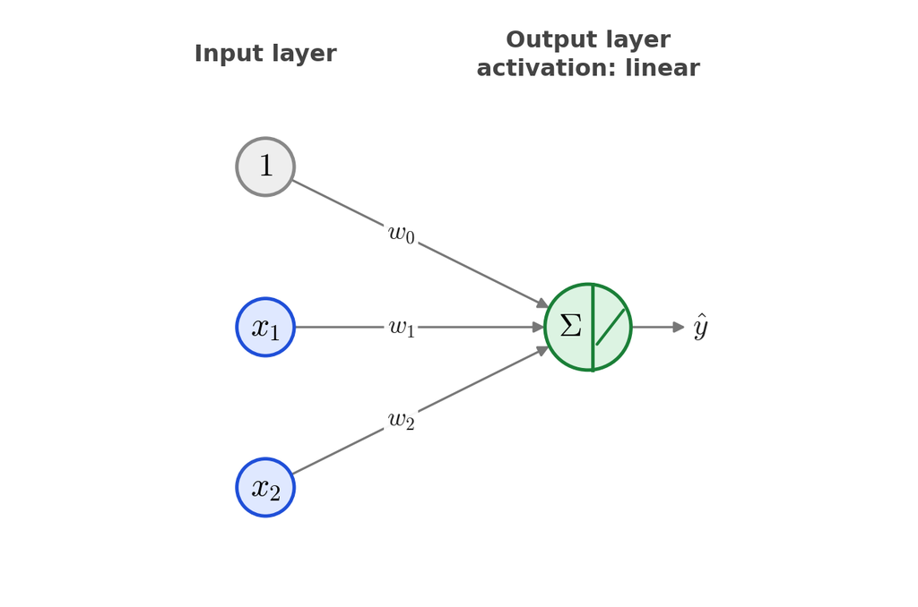

## Inside a Node

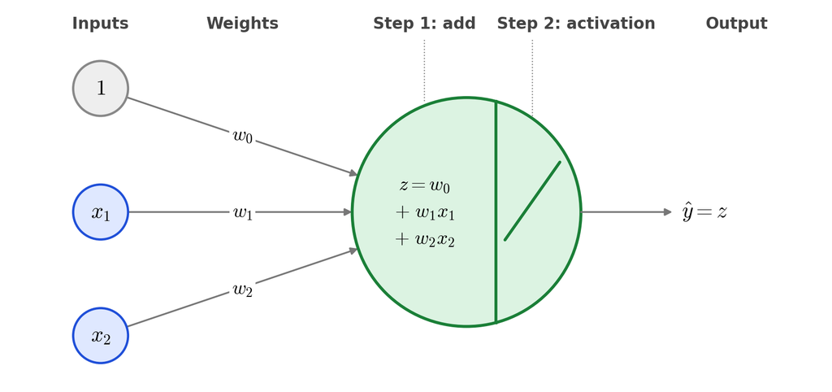

- Every node after the input layer does the same two steps: it **adds** its weighted inputs to get $z$, then applies an **activation function** to $z$.
- In network diagrams, the circle is split in two: $\Sigma$ for the sum, and a small picture of the activation function.
- In the linear model, the activation leaves $z$ unchanged, $\hat{y} = z$, so the picture is a straight line.

## The Same Model, in Two Vocabularies

| Algebraic form | Network form |
| --- | --- |
| Predictors $x_1, x_2$ | Nodes in the **input layer** |
| Coefficients $w_1, w_2$ | **Weights** on the arrows |
| Intercept $w_0$ | **Bias**: the weight on an arrow from a node that always equals 1 |
| Prediction $\hat{y}$ | Node in the **output layer** |
| $\hat{y}$ is just the sum, $\hat{y} = z$ | **Linear activation** in the output node |
| Training: find $w_0, w_1, w_2$ | Training: find all the weights |

A linear model is a neural network with an input layer, an output layer, and nothing in between.

## Linear Model: One Data Point

Algebraic form

Take the second row: $x_1 = 2$, $x_2 = 1$, $y = 0$. Suppose $w_0 = -1$, $w_1 = 0.5$, $w_2 = 0.5$. Blue: the sum going **into** the activation. Red: the value coming **out** of it.

**Before the activation**
$$\begin{gathered}\textcolor{#1f4fd8}{z = -1 + (0.5)(2) + (0.5)(1) = 0.5}\end{gathered}$$

**After the linear activation**
$$\begin{gathered}\textcolor{#b5302a}{\hat{y} = z = 0.5}\end{gathered}$$
The linear activation leaves the value unchanged.

Squared loss for this point: $(\hat{y} - y)^2 = (0.5 - 0)^2 = 0.25$

Network form

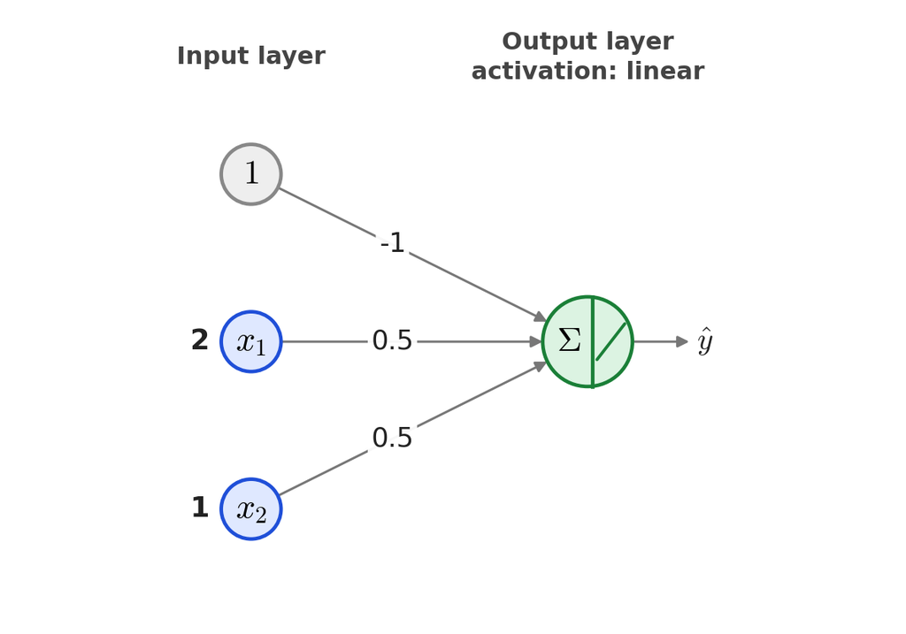

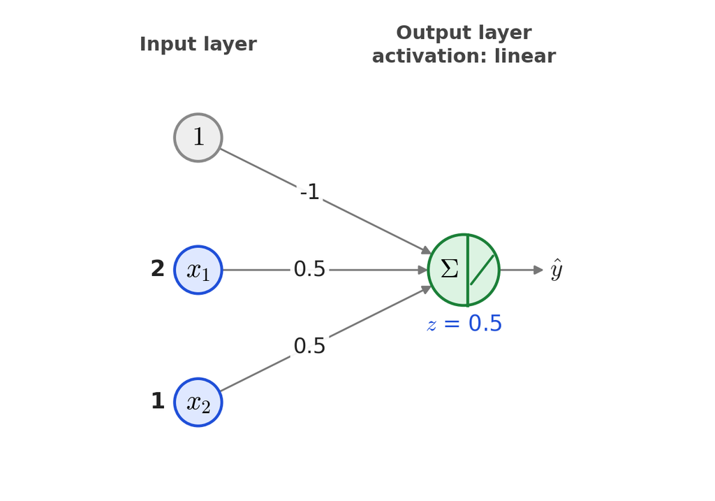

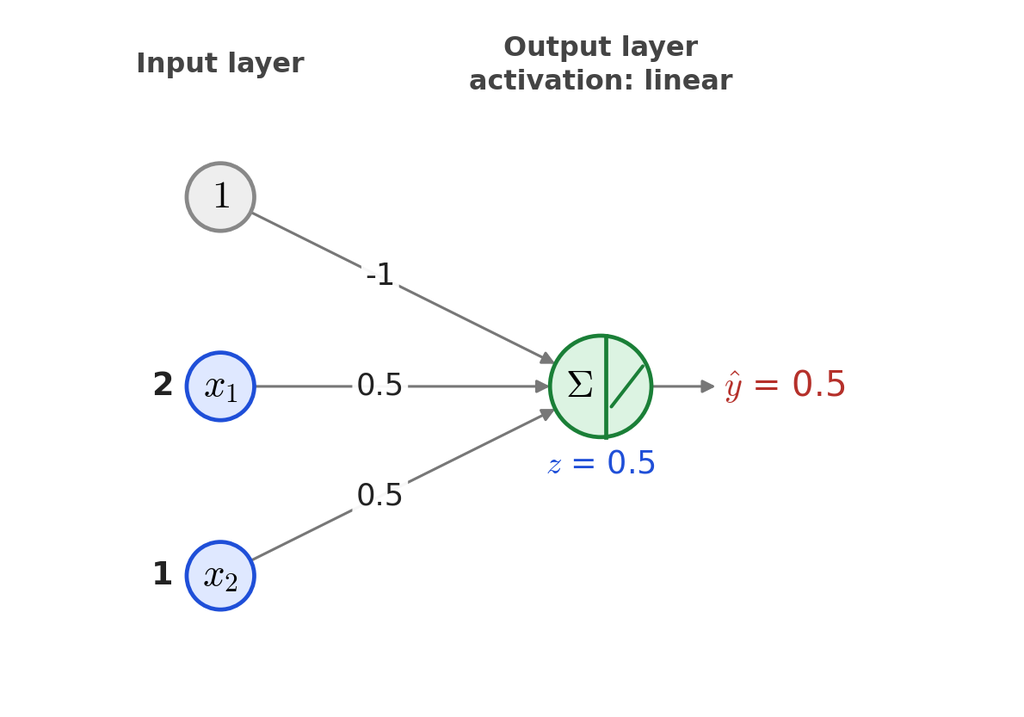

## Your Turn: All Four Rows

Use the same weights: $w_0 = -1$, $w_1 = 0.5$, $w_2 = 0.5$. Send each row through the network.

| $x_1$ | $x_2$ | $y$ | $\hat{y} = w_0 + w_1x_1 + w_2x_2$ | $(\hat{y} - y)^2$ |
| --- | --- | --- | --- | --- |
| 1 | 0 | -2 | -0.5 | 2.25 |
| 2 | 1 | 0 | 0.5 | 0.25 |
| 3 | -2 | -1 | -0.5 | 0.25 |
| 4 | 3 | 1 | 2.5 | 2.25 |

Total loss: $L(-1, 0.5, 0.5) = 5$. Training searches for the weights that make $L$ as small as possible.

## What If We Add a Layer? All Activations Linear

Algebraic form

Hidden layer, linear activation:

$$h_1 = w_{10} + w_{11} x_1 + w_{12} x_2$$

$$h_2 = w_{20} + w_{21} x_1 + w_{22} x_2$$

Output layer, linear activation:

$$\hat{y} = v_0 + v_1 h_1 + v_2 h_2$$

- $w_{ij}$ is the weight into hidden node $i$ from input $j$. $w_{i0}$ is its bias.
- The model grows from **3** parameters to **9**.
- Is this a better model?

Network form

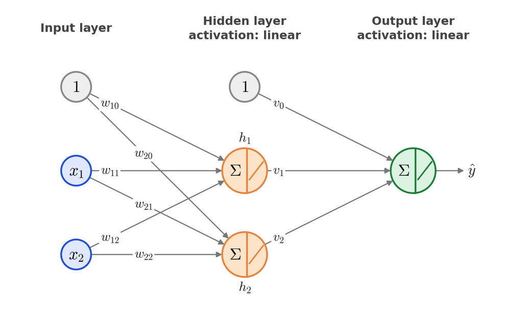

## One Linear Hidden Layer: One Data Point

Algebraic form

Same point as before: $x_1 = 2$, $x_2 = 1$. Blue: the sum going **into** the activation. Red: the value coming **out** of it.

**Hidden layer, before the activation**
$$\begin{gathered}\textcolor{#1f4fd8}{z_{h_1} = 1 + (1)(2) + (-0.5)(1) = 2.5} \\ \textcolor{#1f4fd8}{z_{h_2} = -1 + (-0.5)(2) + (1)(1) = -1}\end{gathered}$$

**Hidden layer, after the linear activation**
$$\begin{gathered}\textcolor{#b5302a}{h_1 = z_{h_1} = 2.5} \\ \textcolor{#b5302a}{h_2 = z_{h_2} = -1}\end{gathered}$$

**Output layer, before the activation**
$$\begin{gathered}\textcolor{#1f4fd8}{z_{\hat{y}} = -1 + (1)(2.5) + (1)(-1) = 0.5}\end{gathered}$$

**Output layer, after the linear activation**
$$\begin{gathered}\textcolor{#b5302a}{\hat{y} = z_{\hat{y}} = 0.5}\end{gathered}$$

This is the same $\hat{y} = 0.5$ we got from the linear model with $w_0 = -1$, $w_1 = 0.5$, $w_2 = 0.5$. Is that a coincidence?

Network form

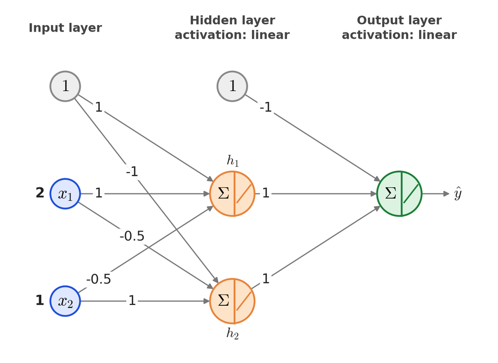

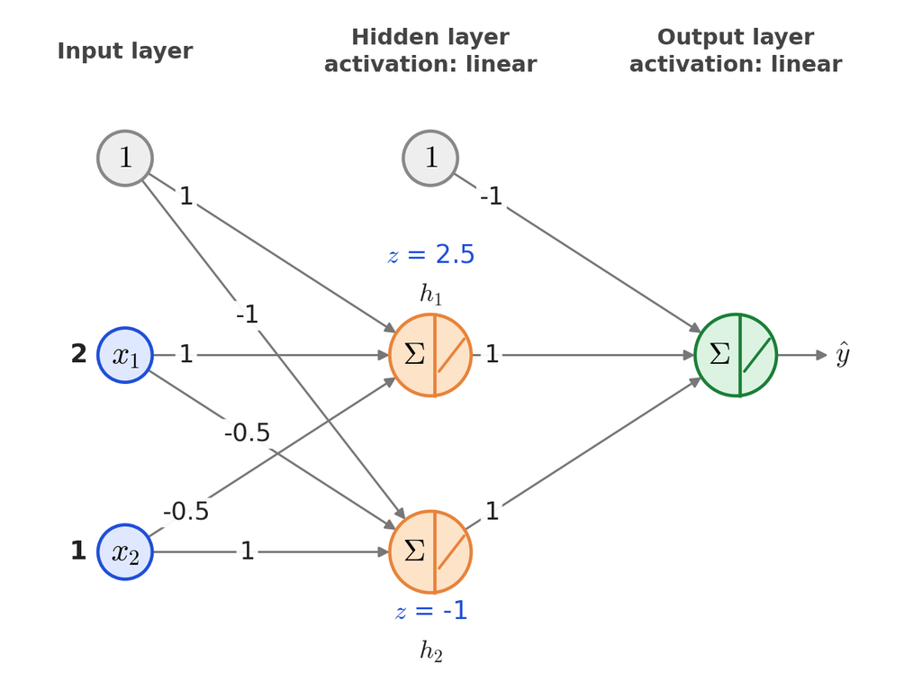

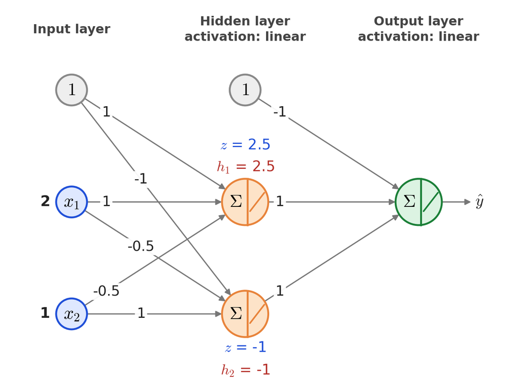

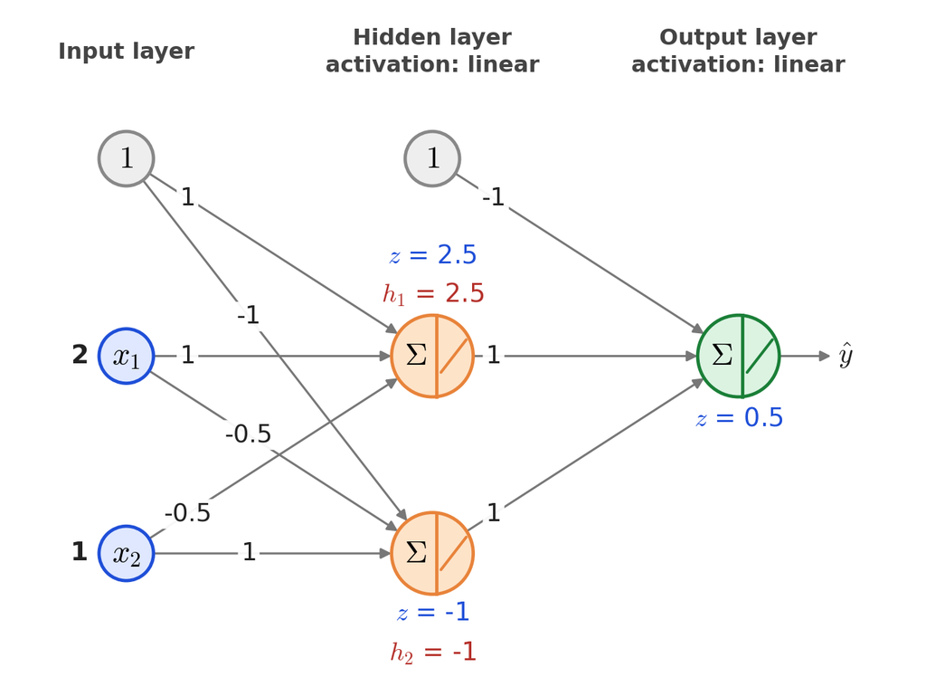

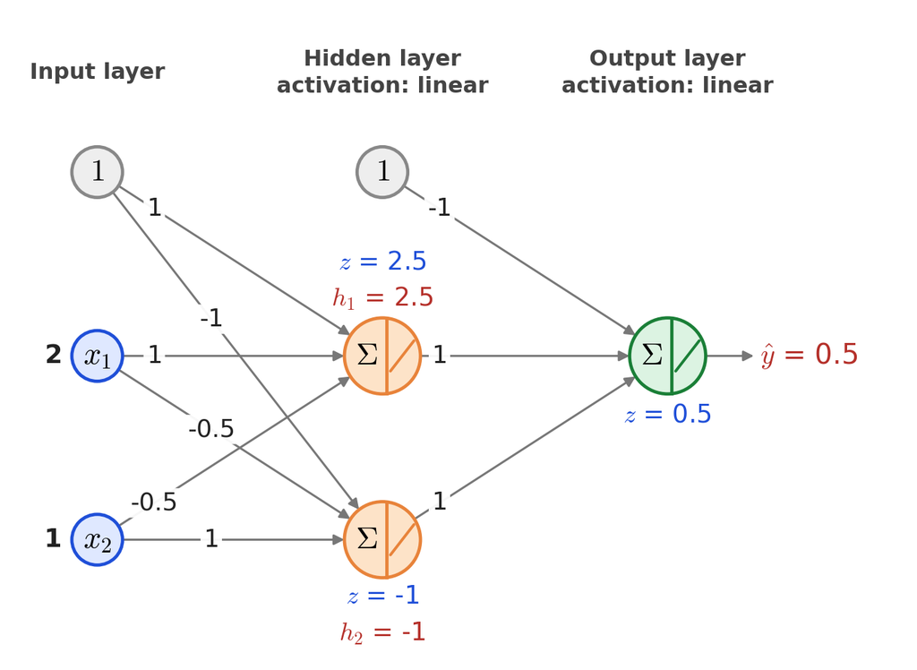

## Why It Is Not a Coincidence

In symbols

Substitute $h_1$ and $h_2$ into $\hat{y}$, then collect terms:

$$\begin{aligned}\hat{y} = {} & (v_0 + v_1 w_{10} + v_2 w_{20}) \\ & + (v_1 w_{11} + v_2 w_{21}) x_1 \\ & + (v_1 w_{12} + v_2 w_{22}) x_2\end{aligned}$$

Each bracket is a single number, so this is

$$\hat{y} = w_0 + w_1 x_1 + w_2 x_2$$

In numbers

With the weights on the last slide:

$$\begin{aligned}w_0 &= -1 + (1)(1) + (1)(-1) = -1 \\ w_1 &= (1)(1) + (1)(-0.5) = 0.5 \\ w_2 &= (1)(-0.5) + (1)(1) = 0.5\end{aligned}$$

These are the weights of the linear model we started with.

A hidden layer with linear activation adds parameters but leaves us with a linear model.

## A Few More Layers: Still All Linear

Algebraic form

Each layer takes linear functions and combines them linearly, so every node is still linear in $x_1, x_2$. Blue: the sum going **into** the activation. Red: the value coming **out** of it.

**Hidden layer 1, before and after**
$$\begin{gathered}\textcolor{#1f4fd8}{z_{h_1} = 1 + (1)(2) + (-0.5)(1) = 2.5} \\ \textcolor{#1f4fd8}{z_{h_2} = -1 + (-0.5)(2) + (1)(1) = -1}\end{gathered}$$
$$\begin{gathered}\textcolor{#b5302a}{h_1 = z_{h_1} = 2.5} \\ \textcolor{#b5302a}{h_2 = z_{h_2} = -1}\end{gathered}$$

**Hidden layer 2, before and after**
$$\begin{gathered}\textcolor{#1f4fd8}{z_{g_1} = 1 + (0.5)(2.5) + (0.5)(-1) = 1.75} \\ \textcolor{#1f4fd8}{z_{g_2} = -1 + (0.5)(2.5) + (0.5)(-1) = -0.25}\end{gathered}$$
$$\begin{gathered}\textcolor{#b5302a}{g_1 = z_{g_1} = 1.75} \\ \textcolor{#b5302a}{g_2 = z_{g_2} = -0.25}\end{gathered}$$

**Output layer, before and after**
$$\begin{gathered}\textcolor{#1f4fd8}{z_{\hat{y}} = -1 + (1)(1.75) + (1)(-0.25) = 0.5}\end{gathered}$$
$$\begin{gathered}\textcolor{#b5302a}{\hat{y} = z_{\hat{y}} = 0.5}\end{gathered}$$

Network form

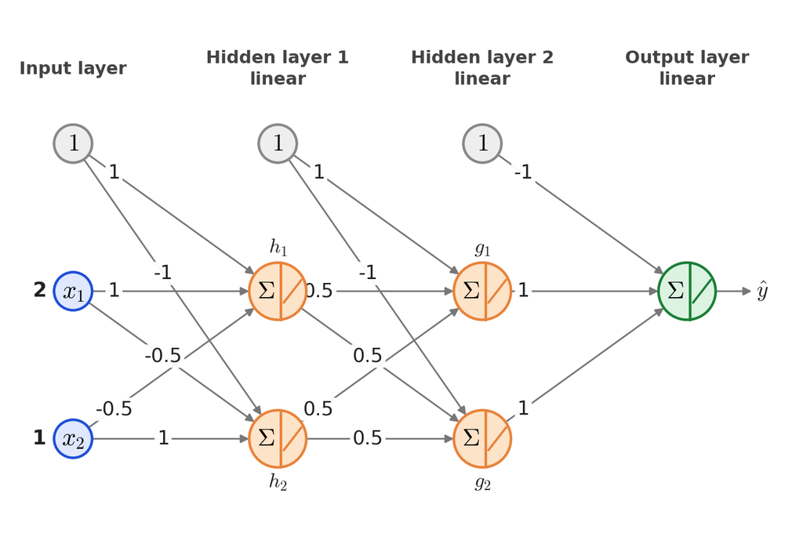

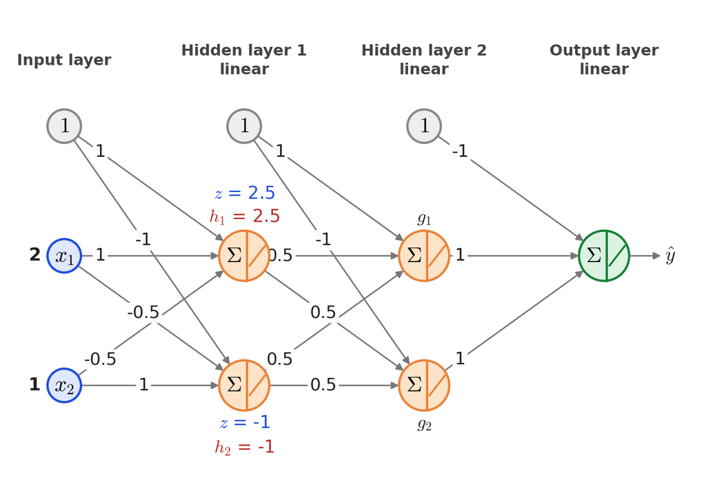

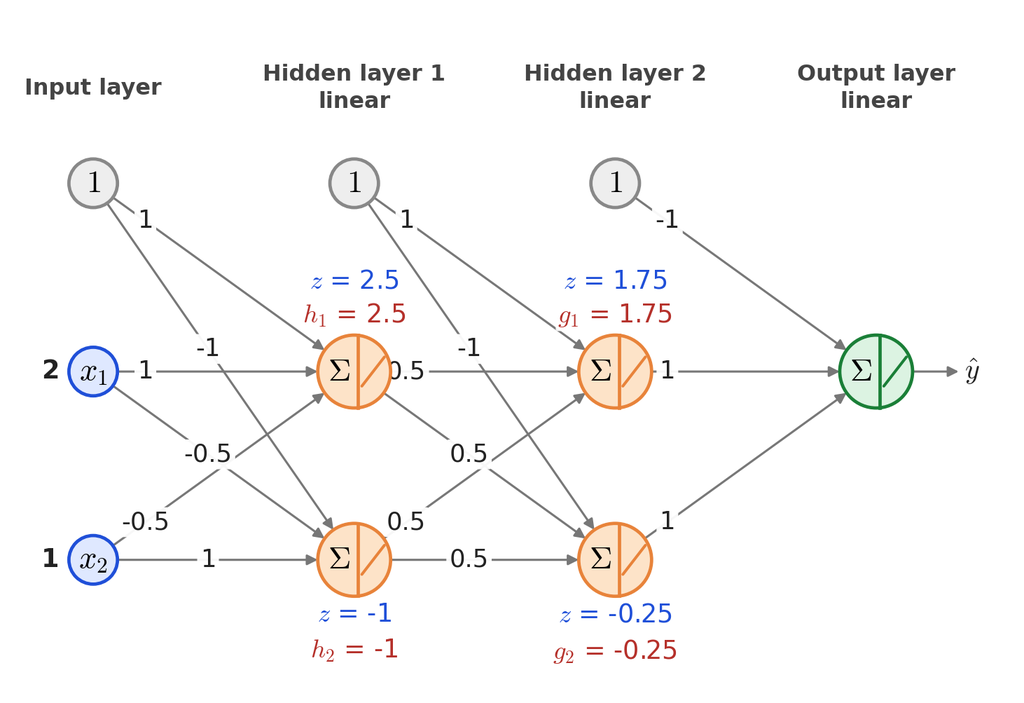

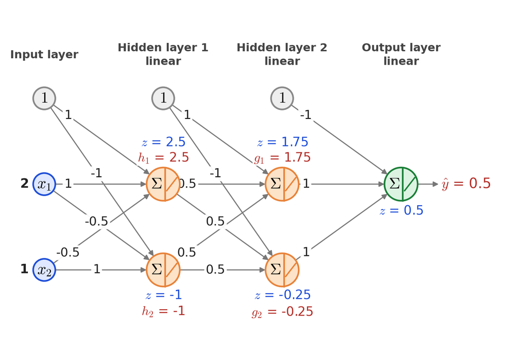

## Three Networks, One Model

| $x_1$ | $x_2$ | $y$ | No hidden layer 3 parameters | 1 linear hidden layer 9 parameters | 2 linear hidden layers 15 parameters |
| --- | --- | --- | --- | --- | --- |
| 1 | 0 | -2 | -0.5 | -0.5 | -0.5 |
| 2 | 1 | 0 | 0.5 | 0.5 | 0.5 |
| 3 | -2 | -1 | -0.5 | -0.5 | -0.5 |
| 4 | 3 | 1 | 2.5 | 2.5 | 2.5 |

- The predictions match on every row, here because we chose the weights that way.
- The general fact: no matter how many linear layers we stack or which weights we pick, the result can always be written as $\hat{y} = w_0 + w_1 x_1 + w_2 x_2$.
- So the extra layers cannot reach a smaller loss than the linear model’s best fit.

More layers help only if the activation functions are **nonlinear**. That leads to logistic regression’s sigmoid and to the networks in Part 3.

# Part 2. Logistic Regression

## Review of Logistic Regression

| $x_1$ | $x_2$ | $y$ |
| --- | --- | --- |
| 1 | 0 | 1 |
| 2 | 1 | 0 |
| 3 | -2 | 0 |
| 4 | 3 | 1 |

- Logistic Regression models $P(y = 1 \mid x) = \hat{y}$ as

$$\hat{y} = \frac{1}{1 + e^{-(w_0 + w_1 x_1 + w_2 x_2)}}$$

- Break this into two steps: add the inputs, then apply an activation function.

$$z = w_0 + w_1 x_1 + w_2 x_2, \qquad \hat{y} = \frac{1}{1 + e^{-z}}$$

- $\dfrac{1}{1 + e^{-z}}$ is the **sigmoid** activation function. It turns any number into a value between 0 and 1.

## Logistic Regression: Two Views

Algebraic form

$$z = w_0 + w_1 x_1 + w_2 x_2$$

$$\hat{y} = \frac{1}{1 + e^{-z}}$$

To compute $\hat{y}$:

1. Multiply each input by its weight.
2. Add the results to $w_0$ to get $z$.
3. Apply the activation function: here the **sigmoid**.

Network form

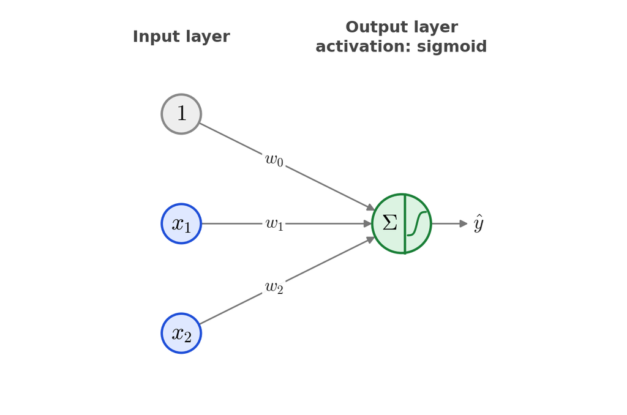

## Logistic Regression: One Data Point

Algebraic form

Same point and same weights as before: $x_1 = 2$, $x_2 = 1$, and now $y = 0$ is a class label. Blue: the sum going **into** the activation. Red: the value coming **out** of it.

**Before the activation**
$$\begin{gathered}\textcolor{#1f4fd8}{z = -1 + (0.5)(2) + (0.5)(1) = 0.5}\end{gathered}$$

**After the sigmoid activation**
$$\begin{gathered}\textcolor{#b5302a}{\hat{y} = \frac{1}{1 + e^{-0.5}} = 0.622}\end{gathered}$$

The model says $P(y = 1 \mid x) = 0.622$, so it predicts class 1. The true class is 0, so these weights get this point wrong and training has work to do.

Network form

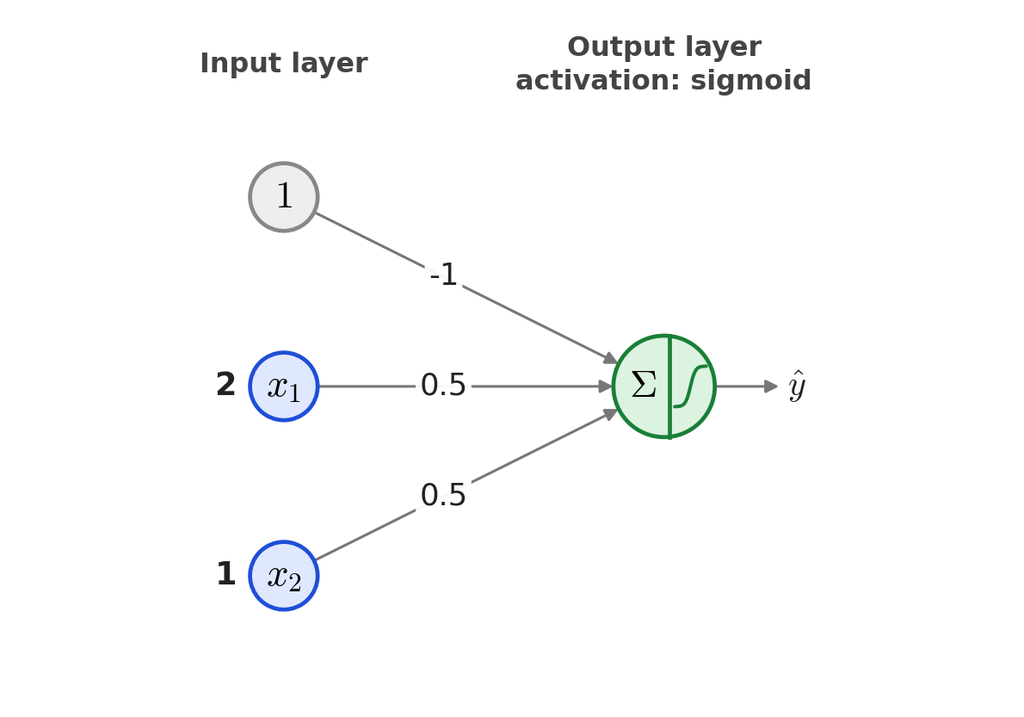

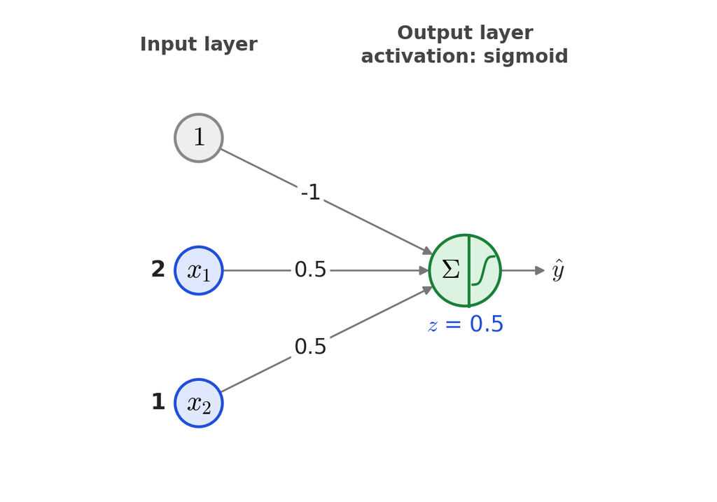

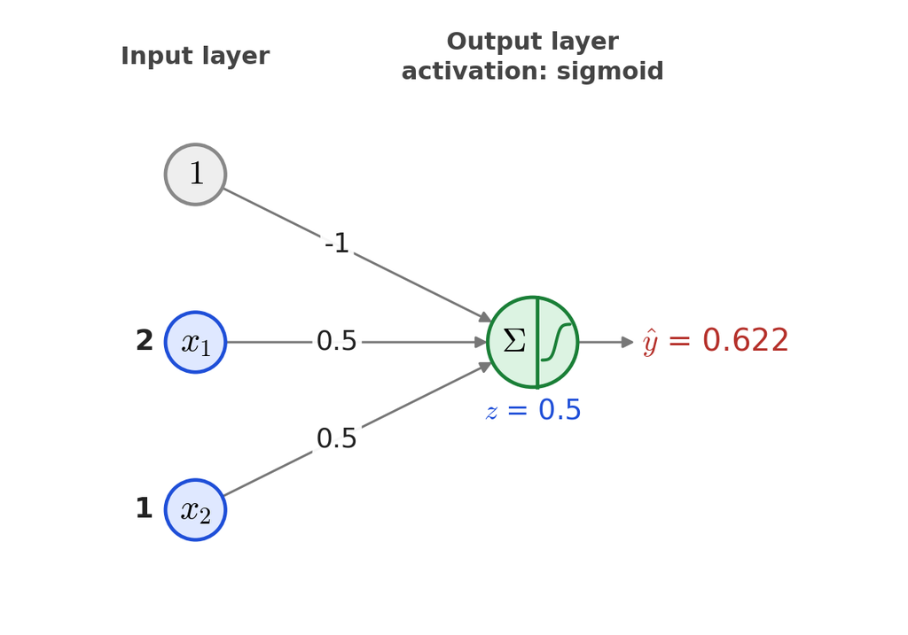

## Inside a Node: Linear vs. Sigmoid

Linear activation

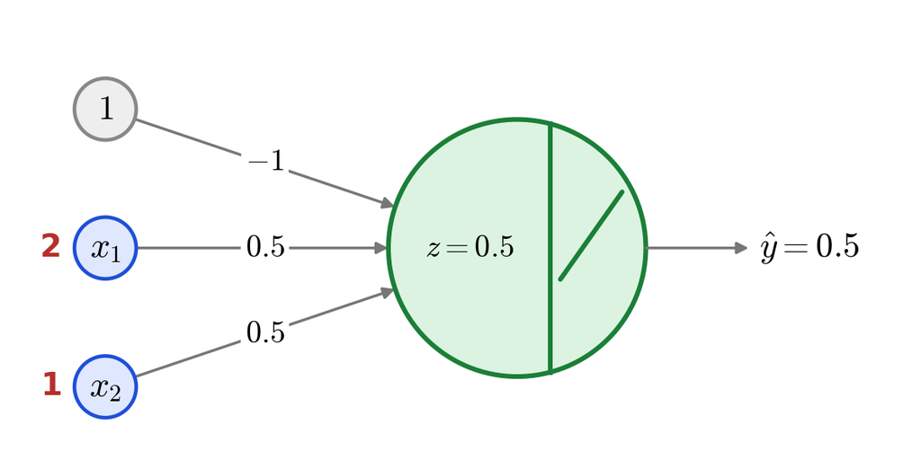

$$\hat{y} = z = 0.5$$

The linear activation leaves $z$ unchanged.

Sigmoid activation

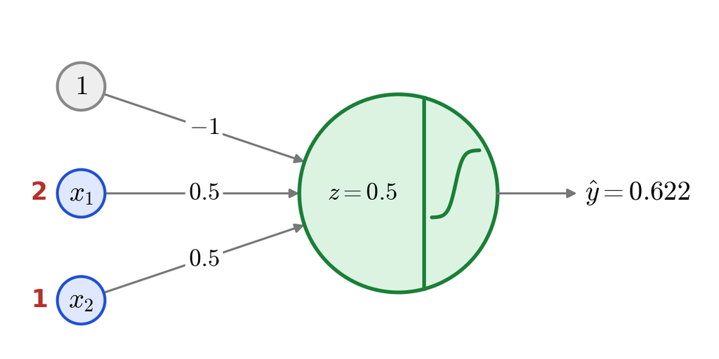

$$\hat{y} = \frac{1}{1 + e^{-0.5}} = 0.622$$

The sigmoid squeezes $z$ into a value between 0 and 1.

Both nodes receive the same inputs with the same weights, so the **sum is the same**. Only the **activation** differs.

## Linear Model and Logistic Regression, Side by Side

Both models start the same way: $z = w_0 + w_1 x_1 + w_2 x_2$. For $x_1 = 2$, $x_2 = 1$ and the same weights, $z = 0.5$.

Linear model

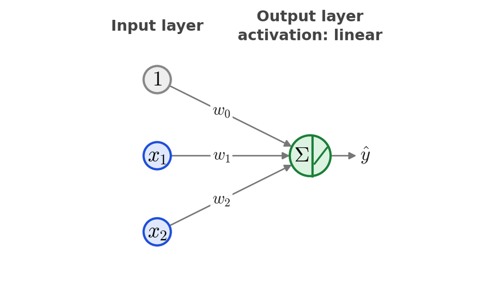

**Activation: linear**

$$\hat{y} = z = 0.5$$

Loss: $l(\hat{y}, y) = (\hat{y} - y)^2$

Logistic regression

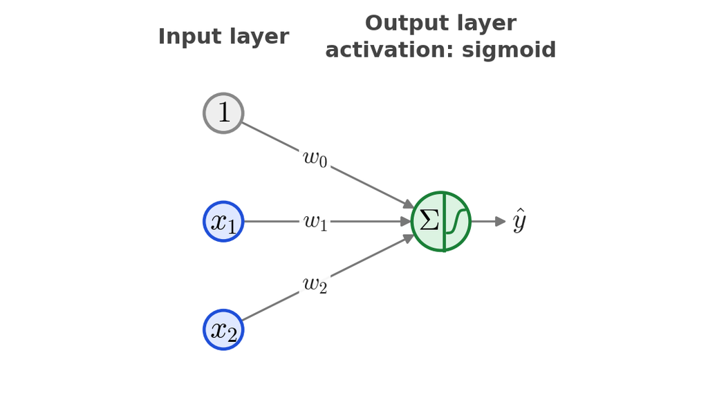

**Activation: sigmoid**

$$\hat{y} = \frac{1}{1 + e^{-z}} = 0.622$$

Loss: $l(\hat{y}, y) = -y \log(\hat{y}) - (1 - y) \log(1 - \hat{y})$

# Part 3. Simple Neural Networks

## Why Do We Need More Than This?

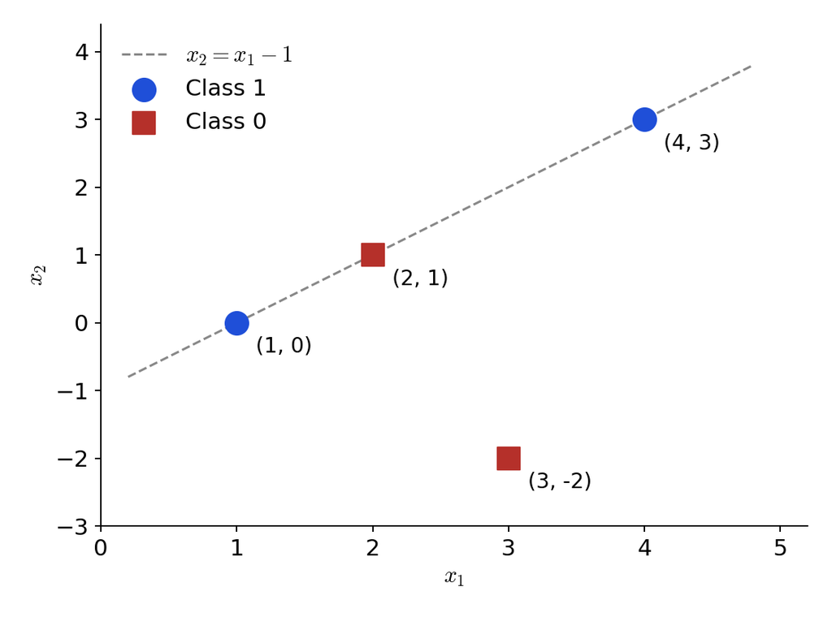

- Logistic regression separates the classes with a **straight line**.
- In our data, $(1, 0)$, $(2, 1)$ and $(4, 3)$ sit on one line, and along it the classes go 1, 0, 1.
- A straight boundary crosses that line only once, so it cannot get all three right.

- Fitted to this data, logistic regression gets 3 of the 4 points right.

**The idea:** feed the inputs through a few logistic regressions first, then combine their outputs. Those in-between nodes form a **hidden layer**.

## Network 1: One Hidden Neuron

Algebraic form

Hidden layer:

$$h = \frac{1}{1 + e^{-(w_{10} + w_{11} x_1 + w_{12} x_2)}}$$

Output layer:

$$\hat{y} = v_0 + v_1 h$$

- $h$ is a logistic regression.
- $\hat{y}$ is a linear model whose only input is $h$.
- **Activations:** sigmoid in the hidden layer, linear in the output layer.
- This network has **5** parameters.

Network form

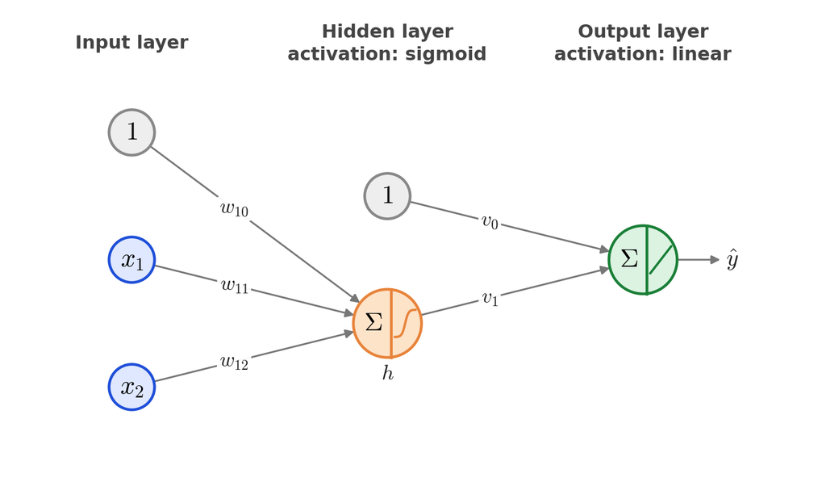

## Network 1: One Data Point

Algebraic form

Input: $x_1 = 2$, $x_2 = 1$, with true value $y = 0$. Each step is rounded to 3 decimals. Blue: the sum going **into** the activation. Red: the value coming **out** of it.

**Hidden layer, before the activation**
$$\begin{gathered}\textcolor{#1f4fd8}{z_h = -1 + (0.5)(2) + (0.5)(1) = 0.5}\end{gathered}$$

**Hidden layer, after the sigmoid**
$$\begin{gathered}\textcolor{#b5302a}{h = \frac{1}{1 + e^{-0.5}} = 0.622}\end{gathered}$$

**Output layer, before the activation**
$$\begin{gathered}\textcolor{#1f4fd8}{z_{\hat{y}} = -1 + (2)(0.622) = 0.244}\end{gathered}$$

**Output layer, after the linear activation**
$$\begin{gathered}\textcolor{#b5302a}{\hat{y} = z_{\hat{y}} = 0.244}\end{gathered}$$

Network form

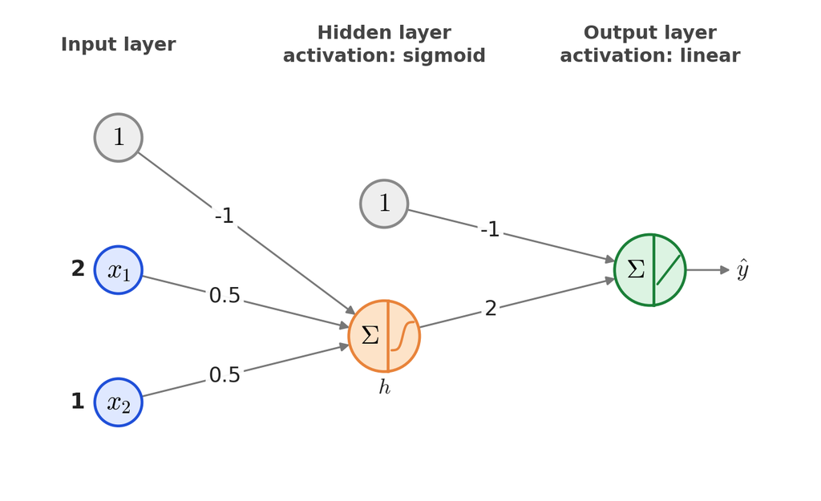

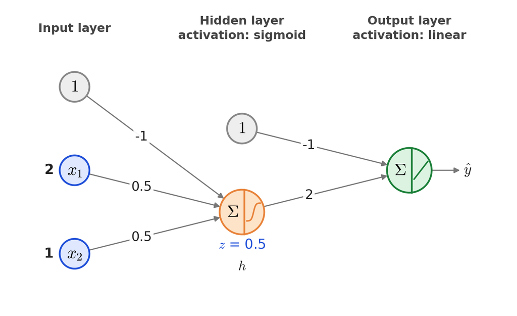

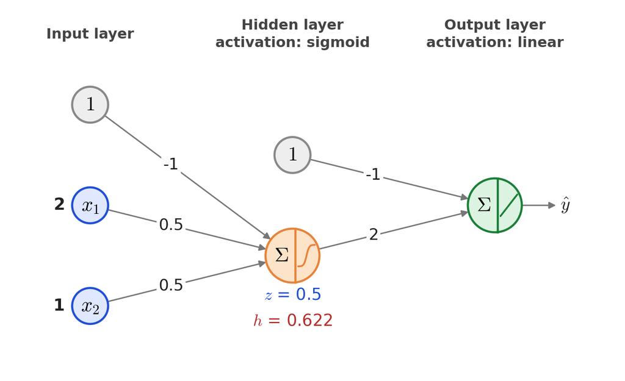

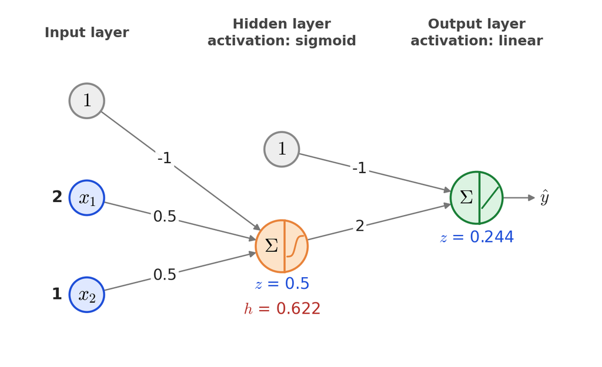

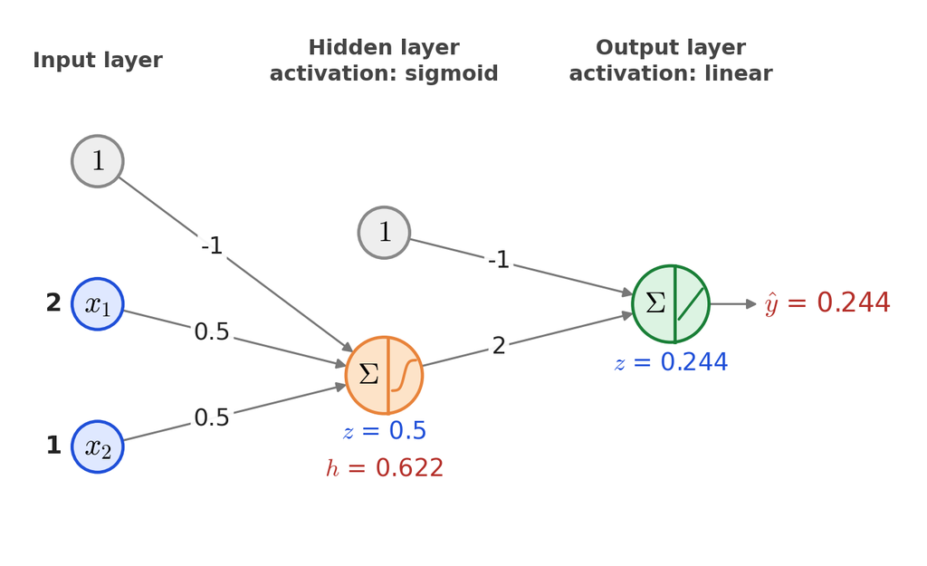

## Network 2: Two Hidden Neurons

Algebraic form

Hidden layer:

$$h_1 = \frac{1}{1 + e^{-(w_{10} + w_{11} x_1 + w_{12} x_2)}}$$

$$h_2 = \frac{1}{1 + e^{-(w_{20} + w_{21} x_1 + w_{22} x_2)}}$$

Output layer:

$$\hat{y} = \frac{1}{1 + e^{-(v_0 + v_1 h_1 + v_2 h_2)}}$$

- $w_{ij}$ is the weight into hidden neuron $i$ from input $j$. $w_{i0}$ is its bias.
- **Activations:** sigmoid in the hidden layer, sigmoid in the output layer.
- This network has **9** parameters.

Network form

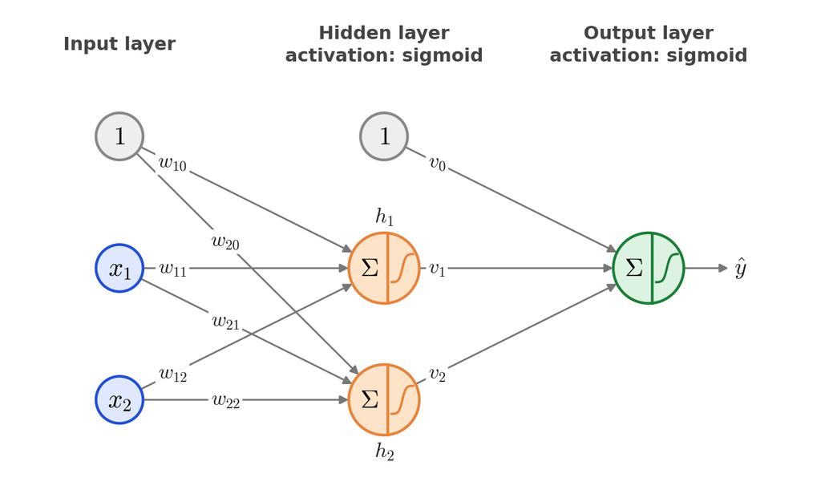